# Data Science Capstone Milestone Report

Georg Vogelhuber

17.7.2015

# Summary

The aim of this project is to target the “Next Word Prediciton” problem (NWP), i.e. to predict the next word in a sentence. The final result of this project will be an algorithm for NWP implemented as shiny app. The NWP feature is commonly found in web search sites or virtual keyboards for mobile applications.

For this project we use mainily the `quanteda`, `tm` and `stringi` packages for dealing with text data and tokenizing inputs.

Our model for the NWP will be based on common n-gram techniques: http://cs.stanford.edu/people/eroberts/courses/soco/projects/2004-05/nlp/techniques_word.html

This milestone report

- describes the available data for this project,
- provides exploratory data analysis and
- gives an outline for the next steps in this project.

# Data acquisition

The data for this project is provided on the course website: https://d396qusza40orc.cloudfront.net/dsscapstone/dataset/Coursera-SwiftKey.zip. The original source of this data is the HC Corpora http://www.corpora.heliohost.org. For this project, we are using the English files. The files have been language filtered but may still contain some foreign text. The text from these files has been scraped from various blogs, newspages and tweets.

For the provided project raw data we have the following summary statistics:

Basic Statistics for data sources (continued below)

|  | File | File.Size | Object.Size |
| --- | --- | --- | --- |
| **Twitter** | en_US.twitter.txt | 167105338 | 316436440 |
| **News** | en_US.news.txt | 205811889 | 261759048 |
| **Blogs** | en_US.blogs.txt | 210160014 | 260564320 |

|  | Lines | Words | Chars |
| --- | --- | --- | --- |
| **Twitter** | 2360148 | 30195092 | 162384825 |
| **News** | 1010242 | 34762395 | 203223154 |
| **Blogs** | 899288 | 37546246 | 206824382 |

The table above contains the following data:

- *File*: filename
- *File.Size*: Size of file in bytes
- *Object.Size*: Size of the corresponding object, after reading file into R.
- *Lines*: Number of lines in file
- *Words*: Number of words in file
- *Chars*: Number of characters in file

# Data cleaning & tokenization

The data mentioned above is loaded into R via `stringi::readLines`. Then a corpus is build for each data set. We take only a random subsample of the provided data for the exploratry data analysis. The entire raw data is too big to process it in reasonable time.

```r
corpus_news <- corpus(sample(news)[1:200000])
```

```
## Non-UTF-8 encoding detected  (windows-1250), converting to UTF-8.
```

```r
corpus_twitter <- corpus(sample(twitter)[1:200000])
```

```
## Non-UTF-8 encoding detected  (windows-1252), converting to UTF-8.
```

```r
corpus_blogs <- corpus(sample(blogs)[1:200000])
```

```
## Non-UTF-8 encoding detected  (windows-1250), converting to UTF-8.
```

Each corpus contains the sampled data together with some meta info.

From this corpora we build document feature matrices via the `dfm` method. This method also performs several cleaning steps:

- convert to lower case
- tokenizing
- remove numbers
- remove punctuation
- remove sepeators
- remove twitter specific characters
- strip additional whitespaces

```r
dfm_news <- dfm(corpus_news)
```

```
## Creating a dfm from a corpus ...
##    ... lowercasing
##    ... tokenizing
##    ... indexing 200,000 documents
##    ... shaping tokens into data.table, found 6,730,092 total tokens
##    ... summing tokens by document
##    ... indexing 122,416 feature types
##    ... building sparse matrix
##    ... created a 200000 x 122416 sparse dfm
##    ... complete. Elapsed time: 18.936 seconds.
```

```r
dfm_twitter <- dfm(corpus_twitter)
```

```
## Creating a dfm from a corpus ...
##    ... lowercasing
##    ... tokenizing
##    ... indexing 200,000 documents
##    ... shaping tokens into data.table, found 2,539,766 total tokens
##    ... summing tokens by document
##    ... indexing 86,106 feature types
##    ... building sparse matrix
##    ... created a 200000 x 86106 sparse dfm
##    ... complete. Elapsed time: 11.722 seconds.
```

```r
dfm_blogs <- dfm(corpus_blogs)
```

```
## Creating a dfm from a corpus ...
##    ... lowercasing
##    ... tokenizing
##    ... indexing 200,000 documents
##    ... shaping tokens into data.table, found 8,276,809 total tokens
##    ... summing tokens by document
##    ... indexing 142,295 feature types
##    ... building sparse matrix
##    ... created a 200000 x 142295 sparse dfm
##    ... complete. Elapsed time: 21.316 seconds.
```

We keep stopwords and do not use word stemming, as we are not interessed in classifying this text, but want to predict the next word to be typed. We also keep profane words, as they can help making predictions for the next word.

Via the `dfm` function we also create document feature matrices for bi- and tri-grams by specifing the `ngram`-parameter.

# Exploratory Data Analysis

## Top 20 Uni- Bi- and Tri-grams

The following barplots show the frequencies for the 20 most frequent uni- bi- and tri-grams:

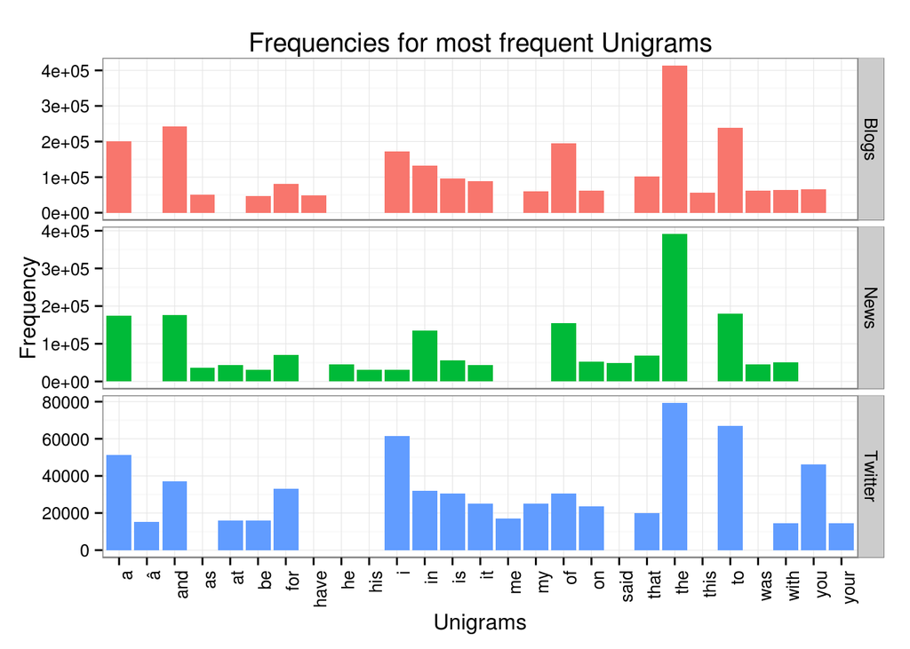

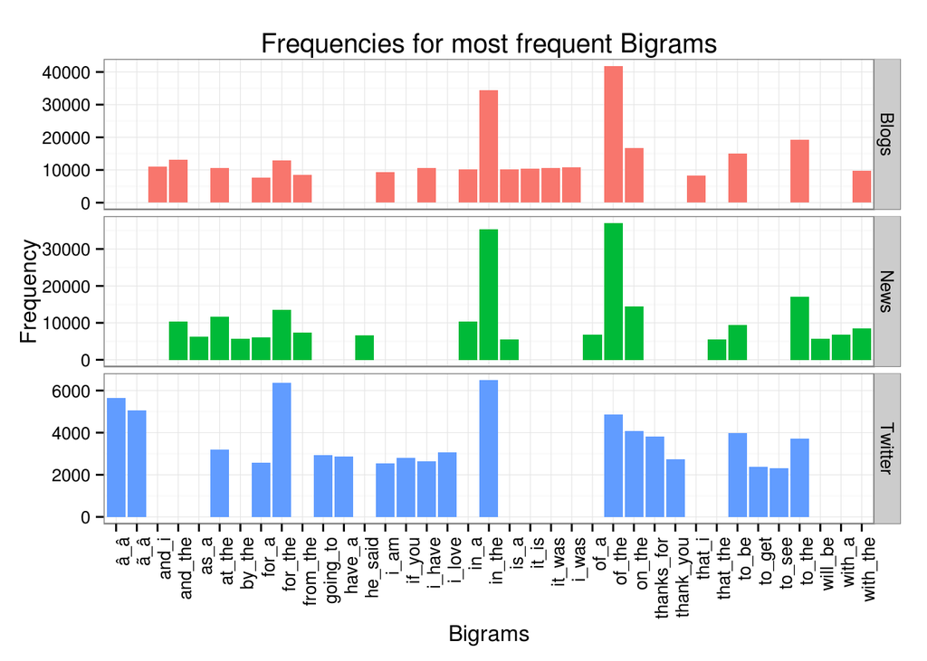

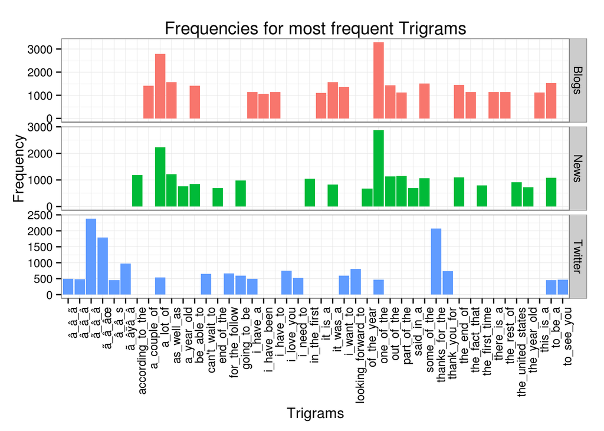

## Number of tokens per document

This histograms show the number of tokens per document of the different sources. A document corresponds to one line in the raw text files and a token represents a word.

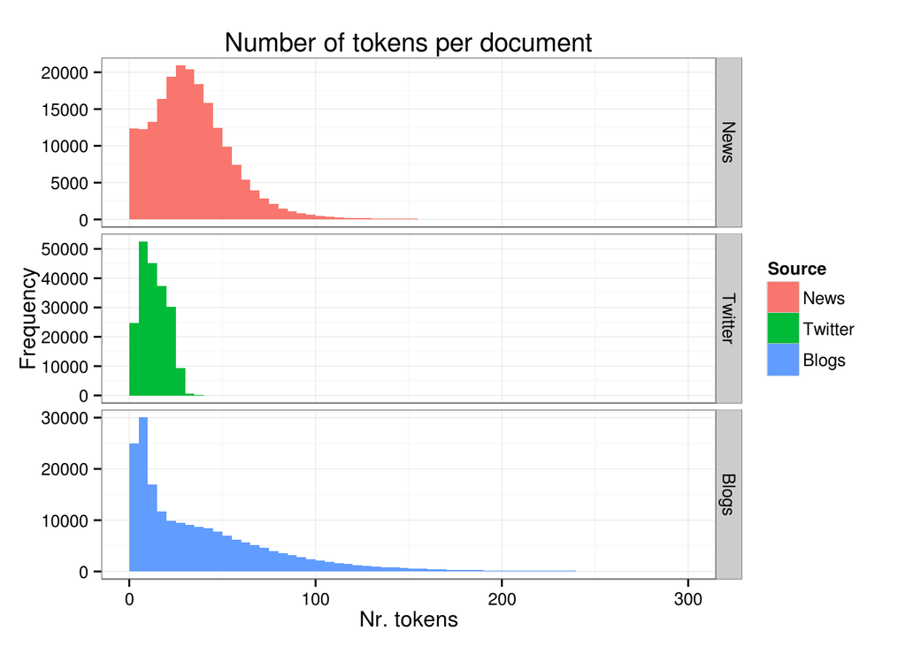

## Number of sentences per document

This histograms show the number of sentences per document of the different sources. A document corresponds to one line in the raw text files.

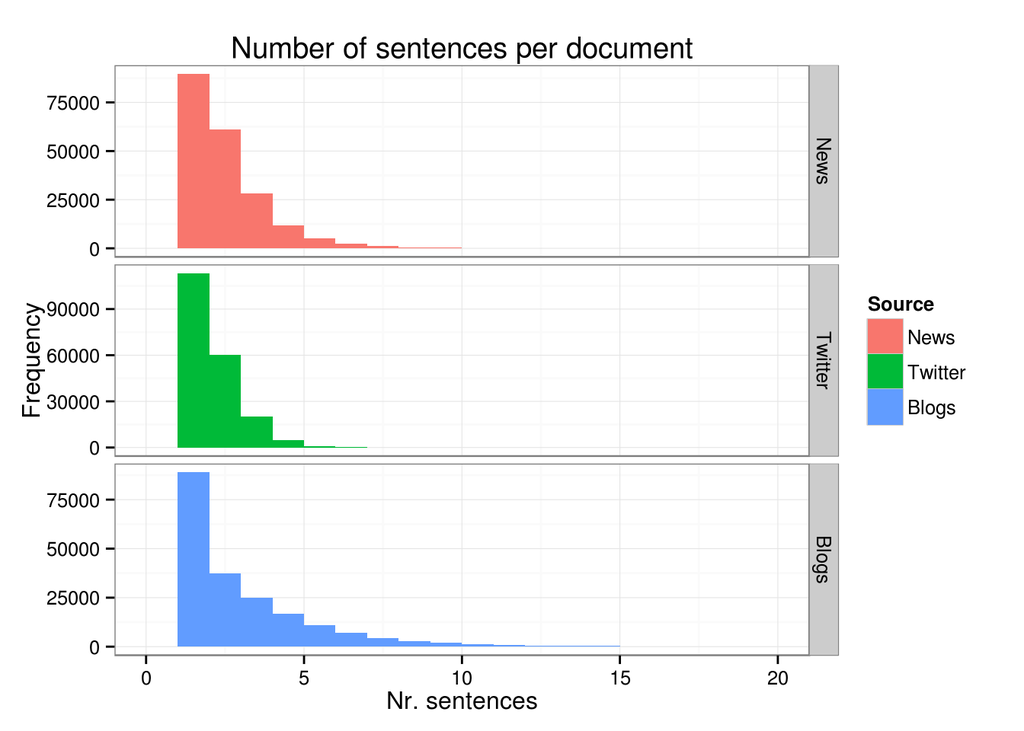

## Number of words vs. corpus covered

The following line plot shows the number of unique words required to cover a certain percentage of the sampled documents.

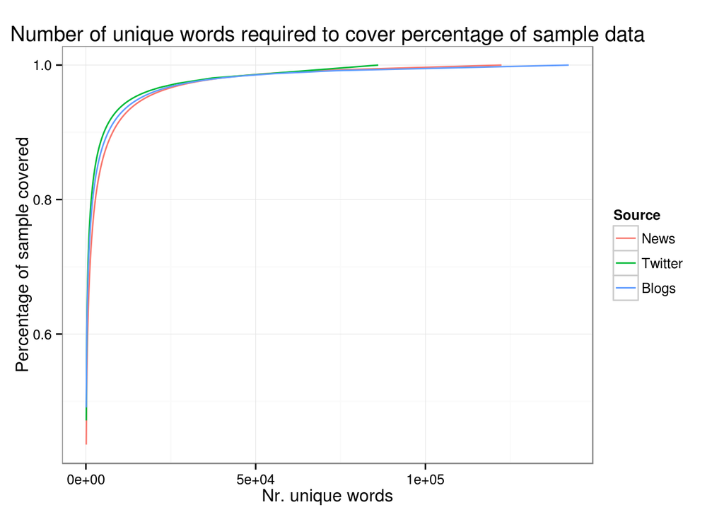

# Next Steps

I plan the following steps to develop and improve the prediciton algorithm:

0. Split data into training, cross-validation and testing set. Build an evaluation function for calculating the accuracy of the model.
1. Build a basic $n$-gram modell using interpolation with $n <= 4$.
2. Split corpus first into sentences, insert a start sentence tag and then build the $n$-gram modell, so the prediciton algorithm takes the beginning of a new sentence into account.
3. Remove documents with fewer than 3 tokens from the modell, as they do not provide enough context for learning the relationship between words.
4. Limit the modell to about 10k words and replace all words not in this list by a tag for “Unknown”. This step should reduce the size of the modell dramatically, so it will possibly run on shiny.
5. Use Kneser-Ney-Smoothing to improve the predictive quality of the algorithm. For an explanation of this method refer to http://mkoerner.de/media/bachelor-thesis.pdf.
6. Increase the value of $n$.
7. Use more data from other sources. Possible sources could be:
- Wikipedia
- Get additional tweets
- Use exisiting corpora from R packages.
8. Implement profanity filtering.